# Case Study: Flight Delays

## Correlation between number of passengers and total number of flights starting at an airport

```r
str(origin_airport_numflights_pass)
```

```
## Classes 'data.table' and 'data.frame':   313 obs. of  4 variables:
##  $ ORIGIN_AIRPORT  : chr  "ABE" "ABI" "ABQ" "ABR" ...
##  $ FLIGHTS_COUNT   : int  954 763 8666 257 326 222 522 512 1666 171 ...
##  $ passengers_count: num  320544 86000 2323883 27595 33949 ...
##  $ pass_per_flight : num  336 113 268 107 104 ...
##  - attr(*, ".internal.selfref")=<externalptr>
##  - attr(*, "sorted")= chr "ORIGIN_AIRPORT"
```

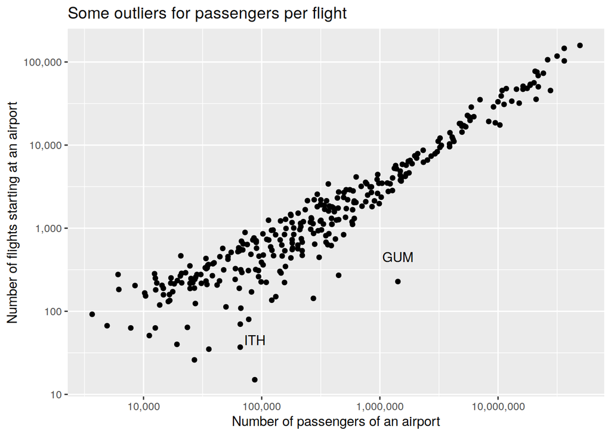

```r
ggplot(origin_airport_numflights_pass, aes(x=passengers_count, y=FLIGHTS_COUNT)) +
  geom_point() +
  annotate("text", x=1420500, y=450, label="GUM") + # 334 flights
  annotate("text", x=87321, y=45, label="ITH") +    # 34 flights
  scale_x_log10(labels = scales::comma) +
  scale_y_log10(labels = scales::comma) +
  labs(x = "Number of passengers of an airport",
       y = "Number of flights starting at an airport",
       title = "Some outliers for passengers per flight")
```

The airports “GUM” (Guam International Airport) and “ITH” (Ithaca Tompkins Regional Airport) look interesting because they have not enough flights for their number of passengers.

```r
origin_airport_numflights_pass[ORIGIN_AIRPORT == "ITH" | ORIGIN_AIRPORT =="GUM"]
```

| ORIGIN_AIRPORT | FLIGHTS_COUNT | passengers_count | pass_per_flight |
| --- | --- | --- | --- |
| GUM | 228 | 1420500 | 6230.263 |
| ITH | 15 | 87321 | 5821.400 |

```r
airports[IATA_CODE == "ITH" | IATA_CODE == "GUM"]
```

| IATA_CODE | AIRPORT | CITY | STATE | COUNTRY | LATITUDE | LONGITUDE |
| --- | --- | --- | --- | --- | --- | --- |
| GUM | Guam International Airport | Agana | GU | USA | 13.48345 | -144.79598 |
| ITH | Ithaca Tompkins Regional Airport | Ithaca | NY | USA | 42.49103 | -76.45844 |

## Correlation between number of passengers and mean/average delay of flights

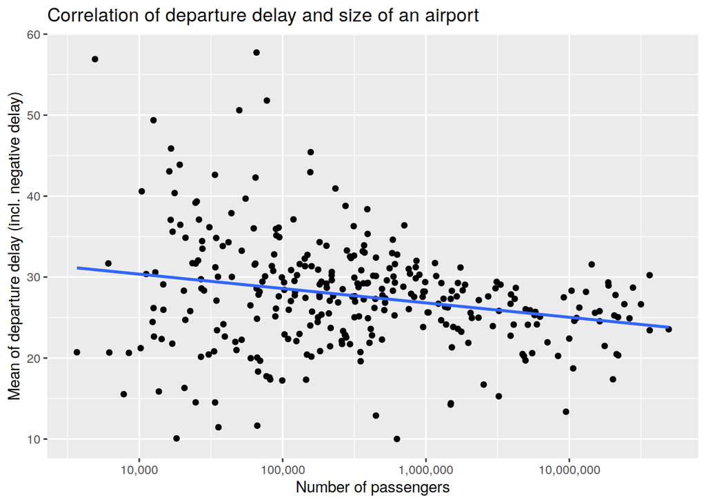

```r
ggplot(origin_airport_delay_pass, aes(passengers_count,mean_D_DELAY)) +
  geom_point() +
  geom_smooth(method = "lm", se=F) +
  scale_x_log10(labels = scales::comma) +
  labs(x = 'Number of passengers',
       y = 'Mean of departure delay (incl. negative delay)',
       title = 'Correlation of departure delay and size of an airport')
```

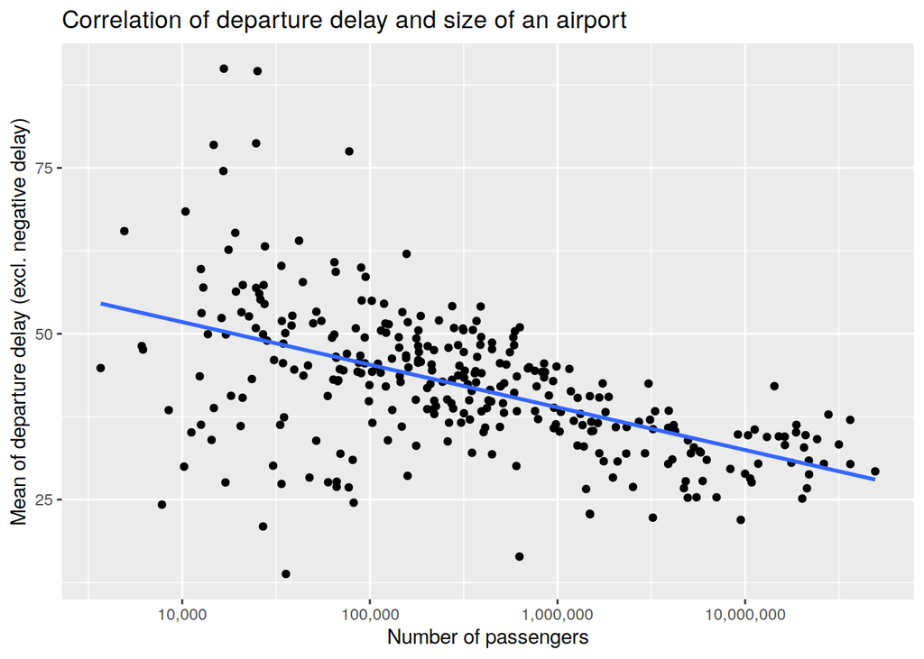

```r
ggplot(origin_airport_delay_pos_pass, aes(passengers_count,mean_D_DELAY)) +
  geom_point() +
  geom_smooth(method = "lm", se=F) +
  scale_x_log10(labels = scales::comma) +
  labs(x = 'Number of passengers',
       y = 'Mean of departure delay (excl. negative delay)',
       title = 'Correlation of departure delay and size of an airport')
```

# Correlation between weather data and delay, in Chicago as an example

To find out if the weather delay caused by the weather of departure airports or the weather of arrival airports, we calculate the correlation between weather delay and departure delay, and the correlation between weather delay and flight time delay.

```r
# delete cancelled and diverted flights
flights1 <- subset(flights0, CANCELLED ==  0 & DIVERTED == 0)

# plotting departure delay caused by wheather
flights_weatherdly <- flights1[flights1$WEATHER_DELAY > 0]

cor(flights_weatherdly$DEPARTURE_DELAY, flights_weatherdly$WEATHER_DELAY)
```

```
## [1] 0.7579244
```

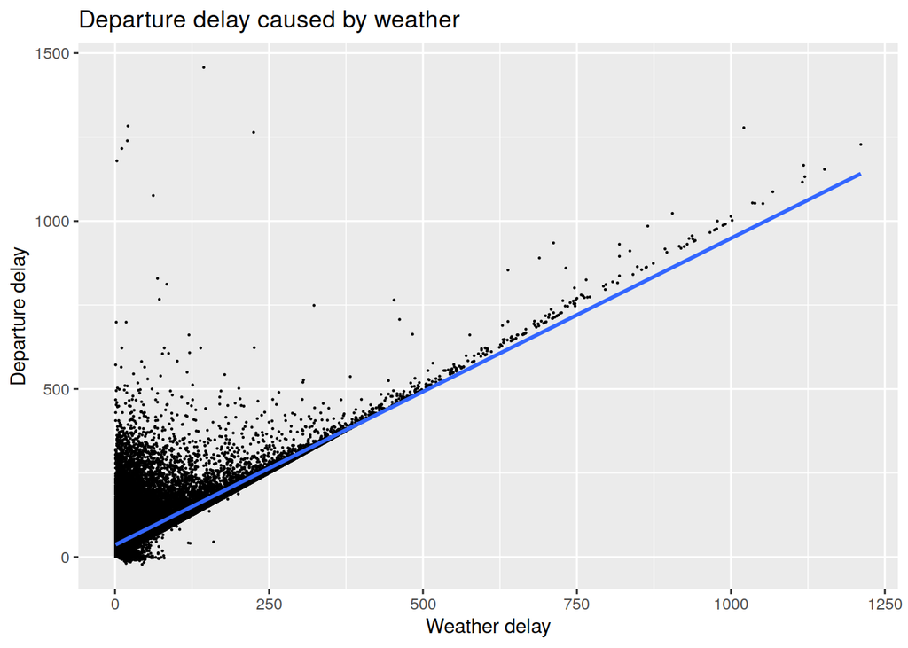

```r
ggplot(flights_weatherdly,
  aes(flights_weatherdly$WEATHER_DELAY, flights_weatherdly$DEPARTURE_DELAY)) +
  geom_point(size=0.1) +
  geom_smooth(method = "lm", se=F) +
  labs(x = 'Weather delay',
       y = 'Departure delay',
       title = 'Departure delay caused by weather')
```

Correlation between departure delay and weather delay is 0.75. we can see a high correlate through the scatter plot.

We calculate the flight time delay to measure the weather delay caused by bad weather of arrival airports.

```r
# calculating flight time delay
flights_weatherdly$FLIGHTTIME_DELAY <- flights_weatherdly$ARRIVAL_DELAY -
  flights_weatherdly$DEPARTURE_DELAY

# plotting flight time daley cause by wheather
cor(flights_weatherdly$FLIGHTTIME_DELAY, flights_weatherdly$WEATHER_DELAY)
```

```
## [1] 0.01234837
```

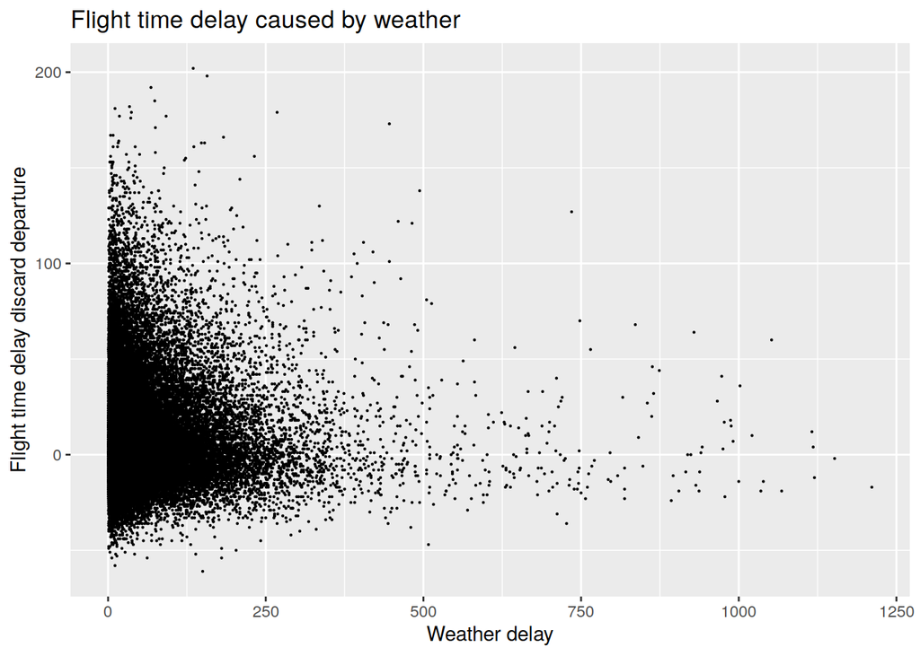

```r
ggplot(flights_weatherdly,
  aes(flights_weatherdly$WEATHER_DELAY, flights_weatherdly$FLIGHTTIME_DELAY)) +
  geom_point(size=0.1) +
  labs(x = 'Weather delay',
       y = 'Flight time delay discard departure',
       title = 'Flight time delay caused by weather')
```

Correlation between flight time delay and weather delay is close to 0. Since the weather of arrival airports has a slight effect on weather delays, we can simply look at the weather of departure airports.

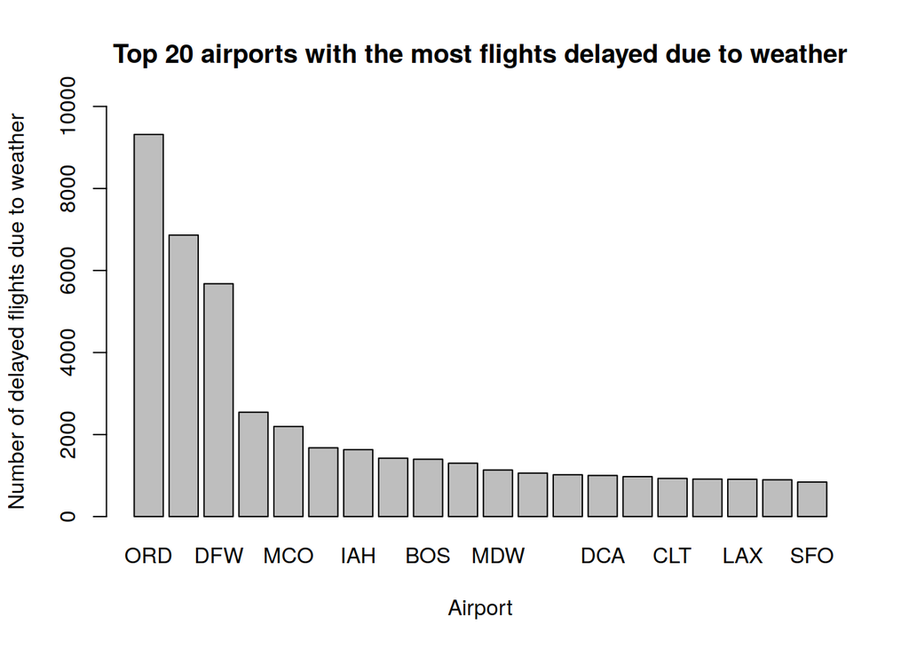

```r
# finding worst wheater airport
org_airport <- table(flights_weatherdly$ORIGIN_AIRPORT)

airport_sort <- sort(org_airport, decreasing = T)
barplot(airport_sort[1:20],
        xlab="Airport",
        ylab="Number of delayed flights due to weather",
        main="Top 20 airports with the most flights delayed due to weather",
        ylim=c(0, 10000))
```

The airport with the biggest weather delay is ORD (Chicago O’Hare). Since daily weather data is publicly available, weather delay can be crossed with weather during the year.

The daily weather data set for Chicago O’Hare international airport was collected from wunderground.com. It recorded daily weather of Chicago O’Hare international airport including temperature, dew point, humidity, wind speed, pressure, and precipitation.

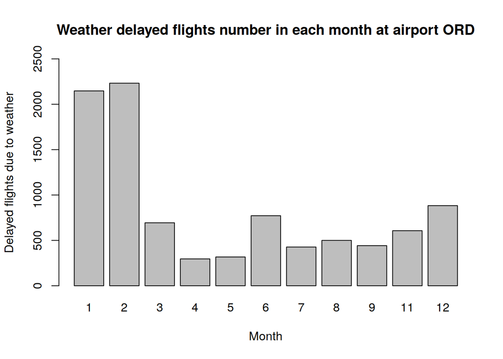

```r
# importing daily ORD weather
ORD_weather <- fread(paste(csv_path, "weatherORD.csv", sep=""))

# weather delay ORD departure flight
ORD_departure_flight <- subset(flights_weatherdly, ORIGIN_AIRPORT == "ORD")

# joining the datasets
ORD_departure_flight$MONTH <- as.integer(ORD_departure_flight$MONTH)
ORD_departure_flight <- left_join(ORD_departure_flight,
                                  ORD_weather, by = c("MONTH", "DAY"))

barplot(table(ORD_departure_flight$MONTH),
        xlab="Month",
        ylab="Delayed flights due to weather",
        main="Weather delayed flights number in each month at airport ORD",
        ylim=c(0, 2500))
```

It is clear to see that the mostly delayed flights are in January and February. For those months, it is possible to see what influenced the most the delays.

```r
ORD_departure_Jan <- subset(ORD_departure_flight, MONTH == 1)
ORD_departure_Feb <- subset(ORD_departure_flight, MONTH == 2)

# correlation between delay and wheather
res3 <- cor(ORD_departure_Jan$DEPARTURE_DELAY, ORD_departure_Jan %>% select(33:48))
round(res3, 2)
```

```
##      Temperature_Max Temperature_Avg Temperature_Min Dew_Point_Max
## [1,]           -0.24           -0.29           -0.34          -0.2
##      Dew_Point_Avg Dew_Point_Min Humidity_Max Humidity_Avg Humidity_Min
## [1,]         -0.27         -0.36        -0.17        -0.12        -0.01
##      Wind_Speed_Max Wind_Speed_Avg Wind_Speed_Min Pressure_Max
## [1,]           0.28           0.27           0.21         0.27
##      Pressure_Avg Pressure_Min Precipitation_Total
## [1,]         0.01         0.03               -0.03
```

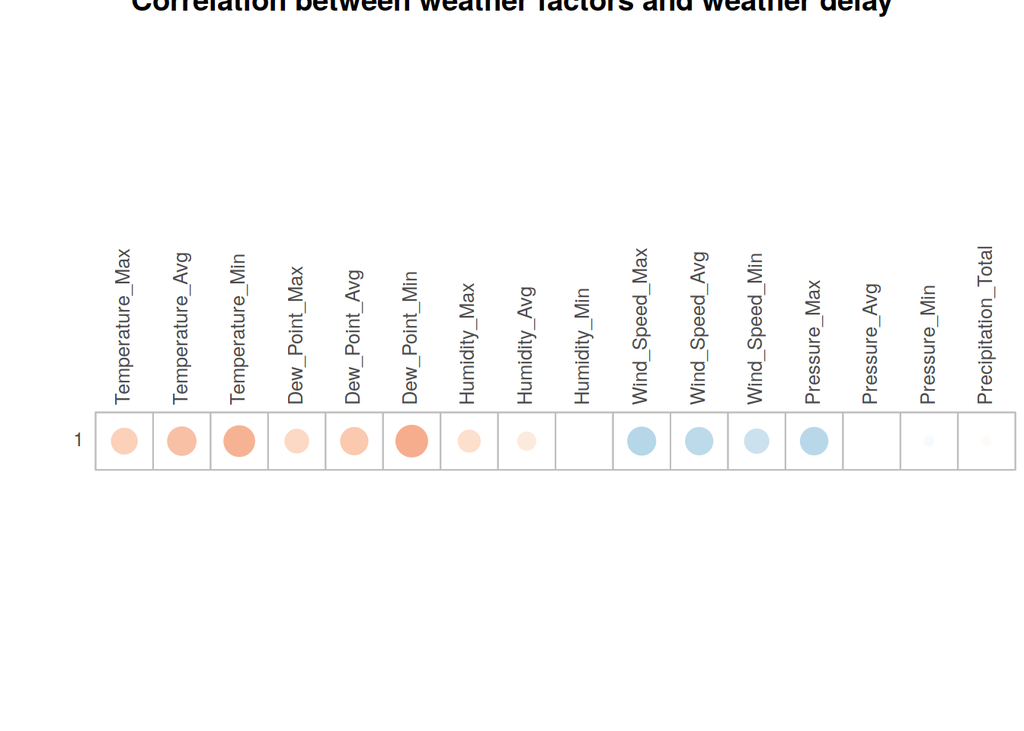

```r
corrplot(res3,
         tl.cex = 0.8,
         tl.col = "gray29",
         cl.pos = "n",
         title = "Correlation between weather factors and weather delay")
```

```r
#res4 <- cor(ORD_departure_Feb$DEPARTURE_DELAY, ORD_departure_Feb %>% select(33:48))
#round(res4, 2)
```

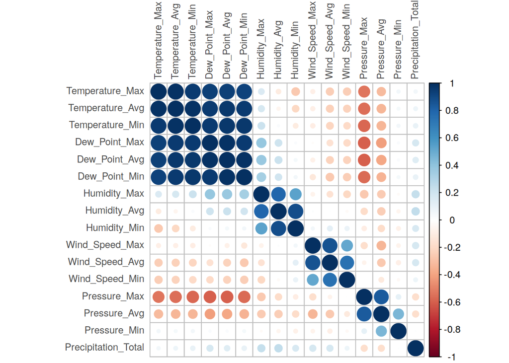

```r
# correlation matrix of weather factors
cor_weather <- ORD_weather %>% select(3:18)
res <- cor(cor_weather)
corrplot(res, tl.cex = 0.8, tl.col = "gray29")
```

Since temperature, dew point, and maximum pressure have a high correlation according to the correlation matrix, we choose only minimum dew point and maximum wind speed as independent variables of the regression model.

```r
# Regression analysis
Jan_two_var <- lm(DEPARTURE_DELAY ~ Dew_Point_Min + Wind_Speed_Max,
                  data = ORD_departure_Jan)
summary(Jan_two_var)
```

```
##
## Call:
## lm(formula = DEPARTURE_DELAY ~ Dew_Point_Min + Wind_Speed_Max,
##     data = ORD_departure_Jan)
##
## Residuals:
##    Min     1Q Median     3Q    Max
## -99.28 -42.59 -14.45  23.68 646.72
##
## Coefficients:
##                Estimate Std. Error t value Pr(>|t|)
## (Intercept)     66.0873     7.6268   8.665   <2e-16 ***
## Dew_Point_Min   -1.9821     0.1751 -11.320   <2e-16 ***
## Wind_Speed_Max   0.2309     0.3785   0.610    0.542
## ---
## Signif. codes:  0 '***' 0.001 '**' 0.01 '*' 0.05 '.' 0.1 ' ' 1
##
## Residual standard error: 64.17 on 2144 degrees of freedom
## Multiple R-squared:  0.1319, Adjusted R-squared:  0.1311
## F-statistic: 162.9 on 2 and 2144 DF,  p-value: < 2.2e-16
```

# Additional Analyses with the data set

## Catch-Up Rate of different airlines [@Yun]

The purpose of this analysis is understanding whether a flights which leaves late is able to arrive on time (catch-up with the delay).

```r
# extracting flights with departure delay but arrival on time
dep_dly_arrv_ontime <- subset(flights1, DEPARTURE_DELAY > 15 & ARRIVAL_DELAY <= 15)
catchup_count <- table(dep_dly_arrv_ontime$AIRLINE)

# extracting flights with noticeable departure delay
dep_dly <- subset(flights1, DEPARTURE_DELAY > 15)
delay_count <- table(dep_dly$AIRLINE)

# catch-up rate of airlines
sort((catchup_count/delay_count)*100, decreasing = T)
```

```
##
##        UA        DL        WN        AA        AS        VX        B6
## 27.290386 26.566317 22.037599 21.358594 19.126606 18.887637 18.720471
##        US        MQ        OO        NK        EV        F9        HA
## 18.389402 14.639858 14.251743 13.684943 13.526581 12.816198  7.999177
```

UA has a catch-up rate of almost 30%, which means flights departing more than 15 minutes late have 30% probability to still arrive on time.

## Clustering

Clustering of airports can be performed using:

- Average distance of outcoming flights;
- Average number of outcoming flights;
- Average number of incoming flights;
- Average number of passengers.

This will likely group the airports in big/small, and delays can be compared according to the clusters.

```r
passengers <- select(airports_pass, IATA_CODE, passengers_count)

flights_cluster <- flights[, .(as.integer(mean(DISTANCE, na.rm = TRUE))), by = .(ORIGIN_AIRPORT)]

outcoming_flights <- flights[ , .N, by = ORIGIN_AIRPORT]
names(outcoming_flights)[1] <- "IATA_CODE"

incoming_flights <- flights[ , .N, by = DESTINATION_AIRPORT]
names(incoming_flights)[1] <- "IATA_CODE"

names(flights_cluster)[1] <- "IATA_CODE"

flights_cluster <- merge(flights_cluster, passengers, by = "IATA_CODE")
flights_cluster <- merge(flights_cluster, incoming_flights, by = "IATA_CODE")
flights_cluster <- merge(flights_cluster, outcoming_flights, by = "IATA_CODE")

flights_cluster <- na.omit(flights_cluster)
flights_cluster$passengers_count <- as.integer(flights_cluster$passengers_count)

# converting to data frame because of row naming
flights_cluster <- data.frame(flights_cluster)
row.names(flights_cluster) <- flights_cluster$IATA_CODE
flights_cluster$IATA_CODE <- NULL

colnames(flights_cluster) <- c("Distance", "Passengers", "Incoming flights", "Outcoming flights")
```

The chosen clustering algorithm is k-means, since it is a simple approach and data is suitable. To calculate the number of clusters, NbClust offers different indexes.

```r
# different indexes to calculate k
ncluster <- NbClust(flights_cluster, min.nc=2, max.nc=20, method="centroid")
```

```
## [1] "Frey index : No clustering structure in this data set"
```

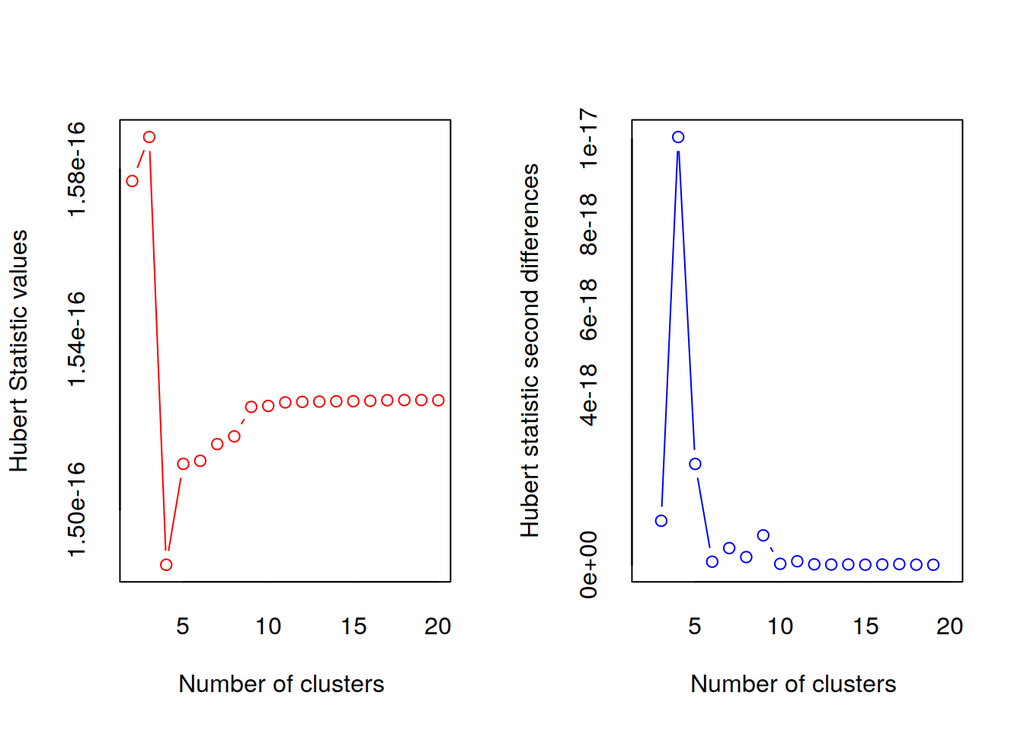

```
## *** : The Hubert index is a graphical method of determining the number of clusters.
##                 In the plot of Hubert index, we seek a significant knee that corresponds to a
##                 significant increase of the value of the measure i.e the significant peak in Hubert
##                 index second differences plot.
##
```

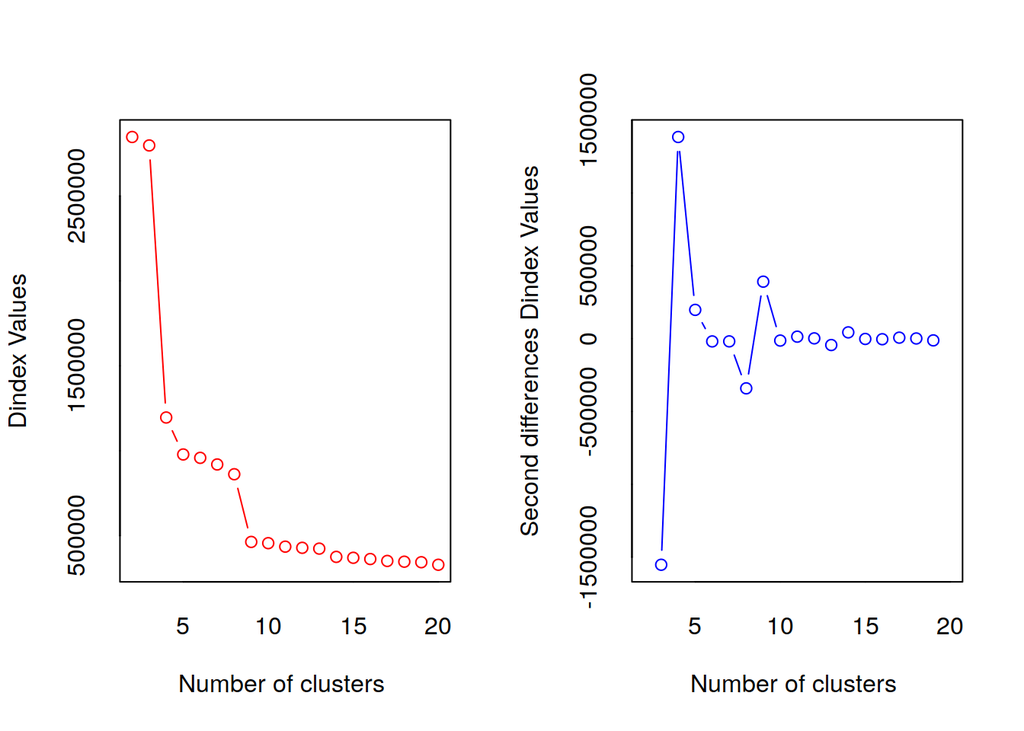

```
## *** : The D index is a graphical method of determining the number of clusters.
##                 In the plot of D index, we seek a significant knee (the significant peak in Dindex
##                 second differences plot) that corresponds to a significant increase of the value of
##                 the measure.
##
## * Among all indices:
## * 3 proposed 2 as the best number of clusters
## * 2 proposed 3 as the best number of clusters
## * 10 proposed 4 as the best number of clusters
## * 1 proposed 5 as the best number of clusters
## * 1 proposed 8 as the best number of clusters
## * 3 proposed 9 as the best number of clusters
## * 1 proposed 10 as the best number of clusters
## * 1 proposed 14 as the best number of clusters
## * 1 proposed 19 as the best number of clusters
##
##                    ***** Conclusion *****
##
## * According to the majority rule, the best number of clusters is  4
##
##
```

```r
# 4 clusters
set.seed(1234)
clusters <- kmeans(flights_cluster, centers=4, iter.max=100, nstart=25)

clusters$size
```

```
## [1]  16  28   4 265
```

```r
clusters$centers
```

```
##    Distance Passengers Incoming flights Outcoming flights
## 1 1024.0000 20134545.6        55674.375         57527.000
## 2  861.8929  6969602.5        23096.679         22674.143
## 3  883.5000 38396877.8       120806.500        131235.500
## 4  470.8717   455178.9         1825.562          1602.223
```

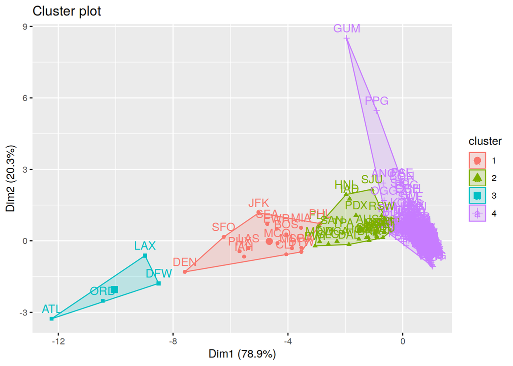

```r
# plotting clusters
fviz_cluster(clusters, data = flights_cluster)
```

A feasible criteria for grouping is:

- Medium/big airports with long distance flights (16);
- Medium airports (28);
- Huge airports (4);
- Small airports (265).

```r
nrow(flights[ORIGIN_AIRPORT %in% rownames(flights_cluster[clusters$cluster == 1, ])])
```

```
## [1] 920432
```

```r
mean(flights[ORIGIN_AIRPORT %in% rownames(flights_cluster[clusters$cluster == 1, ])]
     $DEPARTURE_DELAY, na.rm = TRUE)
```

```
## [1] 25.0114
```

```r
nrow(flights[ORIGIN_AIRPORT %in% rownames(flights_cluster[clusters$cluster == 2, ])])
```

```
## [1] 634876
```

```r
mean(flights[ORIGIN_AIRPORT %in% rownames(flights_cluster[clusters$cluster == 2, ])]
     $DEPARTURE_DELAY, na.rm = TRUE)
```

```
## [1] 23.86624
```

```r
nrow(flights[ORIGIN_AIRPORT %in% rownames(flights_cluster[clusters$cluster == 3, ])])
```

```
## [1] 524942
```

```r
mean(flights[ORIGIN_AIRPORT %in% rownames(flights_cluster[clusters$cluster == 3, ])]
     $DEPARTURE_DELAY, na.rm = TRUE)
```

```
## [1] 26.07805
```

```r
nrow(flights[ORIGIN_AIRPORT %in% rownames(flights_cluster[clusters$cluster == 4, ])])
```

```
## [1] 424589
```

```r
mean(flights[ORIGIN_AIRPORT %in% rownames(flights_cluster[clusters$cluster == 4, ])]
     $DEPARTURE_DELAY, na.rm = TRUE)
```

```
## [1] 26.92377
```

It can be seen that despite the negative correlation between number of passengers and flight delays, the mean of departure delay is similar for each cluster. The interesting values are related to the number of outcoming flights: just 16 airports (5%) are the origin of 36% of flights.

265 small airports only concern 424 589 flights.